# Analysis of the diabetes data set in R

## Libraries

```r
library(tidyverse)
library(ggplot2)
library(gridExtra)
library(tidyr)
library(naniar)
library(visdat)
library(dplyr)
library(mice)
```

## Part 1

## Reading data

```r
diabetes <- read.csv("diabetes.csv", header=T, sep=",")
```

# Descriptive statistics

```r
str(diabetes)
```

```
## 'data.frame':    403 obs. of  22 variables:
##  $ id                  : num  1000 1001 1002 1003 1005 ...
##  $ total_cholesterol   : num  203 165 228 78 249 248 195 227 177 263 ...
##  $ stabilized.glucose  : num  82 97 92 93 90 94 92 75 87 89 ...
##  $ hdl                 : num  56 24 37 12 28 69 41 44 49 40 ...
##  $ total_chol_hdl_ratio: num  3.6 6.9 6.2 6.5 8.9 ...
##  $ glycosoloatedhgb    : num  4.31 4.44 4.64 4.63 7.72 ...
##  $ location            : chr  "Buckingham" "Buckingham" "Buckingham" "Buckingham" ...
##  $ age                 : num  46 29 58 67 64 34 30 37 45 55 ...
##  $ gender              : int  1 1 1 0 0 0 0 0 0 1 ...
##  $ height              : num  62 64 61 67 68 71 69 59 69 63 ...
##  $ weight              : num  121 218 256 119 183 190 191 170 166 202 ...
##  $ bp.1s               : num  118 112 190 110 138 132 161 150 160 108 ...
##  $ bp.1d               : num  59 68 92 50 80 86 112 98 80 72 ...
##  $ waist               : num  29 46 49 33 44 36 46 34 34 45 ...
##  $ hip                 : num  38 48 57 38 41 42 49 39 40 50 ...
##  $ diabetes_diagnosis  : int  0 0 0 0 1 0 0 0 0 0 ...
##  $ BMI                 : num  22.1 37.4 48.4 18.6 27.8 ...
##  $ waist_hip_ratio     : num  0.763 0.958 0.86 0.868 1.073 ...
##  $ BMI_cat_5           : int  1 4 5 1 2 2 2 3 1 4 ...
##  $ age_cat             : int  2 1 3 4 3 1 1 2 2 3 ...
##  $ waist_hip_cat       : int  0 1 1 0 1 0 1 0 0 1 ...
##  $ BMI_cat_3           : int  1 3 3 1 2 2 2 3 1 3 ...
```

```r
summary(diabetes)
```

```
##        id        total_cholesterol stabilized.glucose      hdl
##  Min.   : 1000   Min.   : 78.0     Min.   : 48.0      Min.   : 12.00
##  1st Qu.: 4792   1st Qu.:179.0     1st Qu.: 81.0      1st Qu.: 38.00
##  Median :15766   Median :204.0     Median : 89.0      Median : 46.00
##  Mean   :15978   Mean   :207.8     Mean   :106.7      Mean   : 50.45
##  3rd Qu.:20336   3rd Qu.:230.0     3rd Qu.:106.0      3rd Qu.: 59.00
##  Max.   :41756   Max.   :443.0     Max.   :385.0      Max.   :120.00
##                  NA's   :1                            NA's   :1
##  total_chol_hdl_ratio glycosoloatedhgb   location              age
##  Min.   : 1.500       Min.   : 2.68    Length:403         Min.   :19.00
##  1st Qu.: 3.200       1st Qu.: 4.38    Class :character   1st Qu.:34.00
##  Median : 4.200       Median : 4.84    Mode  :character   Median :45.00
##  Mean   : 4.522       Mean   : 5.59                       Mean   :46.85
##  3rd Qu.: 5.400       3rd Qu.: 5.60                       3rd Qu.:60.00
##  Max.   :19.300       Max.   :16.11                       Max.   :92.00
##  NA's   :1            NA's   :13
##      gender           height          weight          bp.1s
##  Min.   :0.0000   Min.   :52.00   Min.   : 99.0   Min.   : 90.0
##  1st Qu.:0.0000   1st Qu.:63.00   1st Qu.:151.0   1st Qu.:121.5
##  Median :1.0000   Median :66.00   Median :172.5   Median :136.0
##  Mean   :0.5806   Mean   :66.02   Mean   :177.6   Mean   :136.9
##  3rd Qu.:1.0000   3rd Qu.:69.00   3rd Qu.:200.0   3rd Qu.:146.5
##  Max.   :1.0000   Max.   :76.00   Max.   :325.0   Max.   :250.0
##                   NA's   :5       NA's   :1
##      bp.1d            waist            hip        diabetes_diagnosis
##  Min.   : 48.00   Min.   :26.00   Min.   :30.00   Min.   :0.0000
##  1st Qu.: 75.00   1st Qu.:33.00   1st Qu.:39.00   1st Qu.:0.0000
##  Median : 82.00   Median :37.00   Median :42.00   Median :0.0000
##  Mean   : 83.37   Mean   :37.89   Mean   :43.05   Mean   :0.1538
##  3rd Qu.: 91.00   3rd Qu.:41.00   3rd Qu.:46.00   3rd Qu.:0.0000
##  Max.   :124.00   Max.   :56.00   Max.   :64.00   Max.   :1.0000
##                                                   NA's   :13
##       BMI        waist_hip_ratio    BMI_cat_5        age_cat
##  Min.   :15.20   Min.   :0.6818   Min.   :1.000   Min.   :1.00
##  1st Qu.:24.13   1st Qu.:0.8295   1st Qu.:1.000   1st Qu.:1.00
##  Median :27.80   Median :0.8788   Median :2.000   Median :2.00
##  Mean   :28.78   Mean   :0.8805   Mean   :2.299   Mean   :2.33
##  3rd Qu.:32.24   3rd Qu.:0.9250   3rd Qu.:3.000   3rd Qu.:3.00
##  Max.   :55.78   Max.   :1.1429   Max.   :5.000   Max.   :4.00
##  NA's   :6                        NA's   :12
##  waist_hip_cat     BMI_cat_3
##  Min.   :0.000   Min.   :1.000
##  1st Qu.:0.000   1st Qu.:1.000
##  Median :1.000   Median :2.000
##  Mean   :0.737   Mean   :2.069
##  3rd Qu.:1.000   3rd Qu.:3.000
##  Max.   :1.000   Max.   :3.000
##  NA's   :19      NA's   :12
```

```r
head(diabetes)
```

```
##     id total_cholesterol stabilized.glucose hdl total_chol_hdl_ratio
## 1 1000               203                 82  56                  3.6
## 2 1001               165                 97  24                  6.9
## 3 1002               228                 92  37                  6.2
## 4 1003                78                 93  12                  6.5
## 5 1005               249                 90  28                  8.9
## 6 1008               248                 94  69                  3.6
##   glycosoloatedhgb   location age gender height weight bp.1s bp.1d waist hip
## 1             4.31 Buckingham  46      1     62    121   118    59    29  38
## 2             4.44 Buckingham  29      1     64    218   112    68    46  48
## 3             4.64 Buckingham  58      1     61    256   190    92    49  57
## 4             4.63 Buckingham  67      0     67    119   110    50    33  38
## 5             7.72 Buckingham  64      0     68    183   138    80    44  41
## 6             4.81 Buckingham  34      0     71    190   132    86    36  42
##   diabetes_diagnosis      BMI waist_hip_ratio BMI_cat_5 age_cat waist_hip_cat
## 1                  0 22.12877       0.7631579         1       2             0
## 2                  0 37.41553       0.9583333         4       1             1
## 3                  0 48.36549       0.8596491         5       3             1
## 4                  0 18.63600       0.8684211         1       4             0
## 5                  1 27.82202       1.0731707         2       3             1
## 6                  0 26.49673       0.8571429         2       1             0
##   BMI_cat_3
## 1         1
## 2         3
## 3         3
## 4         1
## 5         2
## 6         2
```

```r
unique(diabetes$diabetes_diagnosis)
```

```
## [1]  0  1 NA
```

```r
unique(diabetes$gender)
```

```
## [1] 1 0
```

```r
# Identify columns that are either integer or character
columns_to_convert <- mapply(function(x) is.integer(x) | is.character(x), diabetes)

# Factor the categorical variables
diabetes[, columns_to_convert] <- lapply(diabetes[,columns_to_convert], factor)
```

The dataset consists of 403 records with 22 variables. It appears that columns diabetes_diagnosis, gender, location, BMI_cat_3, BMI_cat_5, age_cat, and waist_hip_cat are categorical, while all other columns are of the numeric type. Additionally, it is observed that certain variables contain missing values (NA).

### Checking for missing values

#### Count how many (%) of all 403 rows are complete.

```r
sum(complete.cases(diabetes))
```

```
## [1] 360
```

```r
nrow(diabetes[complete.cases(diabetes), ])/nrow(diabetes)*100
```

```
## [1] 89.33002
```

Hence, 43 rows or 10.6699752% of rows have at least one missing value.

#### Investigating missing values per column

```r
colSums(is.na(diabetes))
```

```
##                   id    total_cholesterol   stabilized.glucose
##                    0                    1                    0
##                  hdl total_chol_hdl_ratio     glycosoloatedhgb
##                    1                    1                   13
##             location                  age               gender
##                    0                    0                    0
##               height               weight                bp.1s
##                    5                    1                    0
##                bp.1d                waist                  hip
##                    0                    0                    0
##   diabetes_diagnosis                  BMI      waist_hip_ratio
##                   13                    6                    0
##            BMI_cat_5              age_cat        waist_hip_cat
##                   12                    0                   19
##            BMI_cat_3
##                   12
```

Missing values :

total_cholesterol = 1  
hdl = 1  
total_chol_hdl_ratio = 1  
weight = 1  
height = 5  
BMI = 6  
BMI_cat_5 = 12  
BMI_cat_3 = 12  
glycosoloatedhgb = 13  
diabetes_diagnosis = 13  
waist_hip_cat = 19

### Checking for outliers

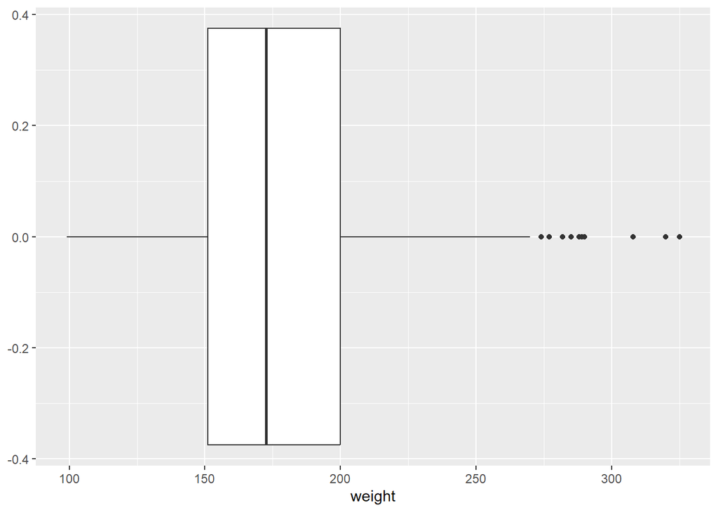

```r
ggplot(diabetes, aes(weight)) +
  geom_boxplot()
```

It appears that there are some outliers on the weight variable. However, in medical datasets like those related to diabetes, extreme values might be valid and biologically meaningful. Hence, extremely high weights may be associated with specific medical conditions. Removing such values could lead to the loss of important information.

Similarly, this principle applies to the remaining variables, and as a result, I have opted not to eliminate any outliers within this dataset.

# Data Visualization

#### Visualizing the categorical columns

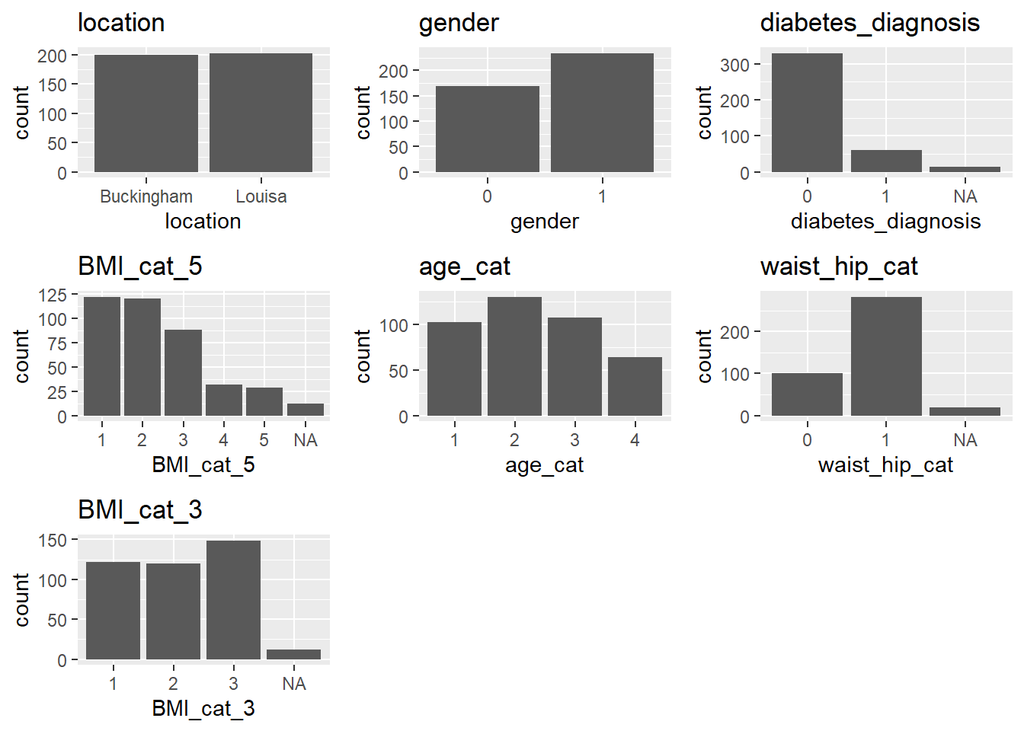

```r
# Identify non-numeric variables
non_numeric_vars <- sapply(diabetes, function(x) !is.numeric(x))

# Create a list of ggplot objects for each categorical variable
plots <- lapply(names(diabetes)[non_numeric_vars], function(var) {
  ggplot(diabetes, aes(factor(get(var)))) +
    geom_bar(position="dodge") +
    labs(title = var, x = var)})

# Arrange the plots in a grid
grid.arrange(grobs = plots, ncol = 3)
```

Assuming that the target class is diabetes_diagnosis the above graph shows that the data is unbalanced. The number of non-diabetic is 330 and the number of diabetic patients is 60.

The dataset exhibits a roughly equal distribution of individuals from both locations, with gender 0 having slightly fewer representatives than gender 1. The waist_hip_cat variable appears somewhat unbalanced as well.

Upon dividing BMI into three categories, the distribution appears nearly uniform, but when categorized into five groups, there is a noticeable decrease in distribution as BMI values increase. It seems that fewer people have higher BMI values, and there is a concentration of individuals in the lower BMI categories.

The age distribution peaks at the second category and slowly decreases as age increases. (Assuming the categories are ordinal)

#### Visualizing the numerical columns

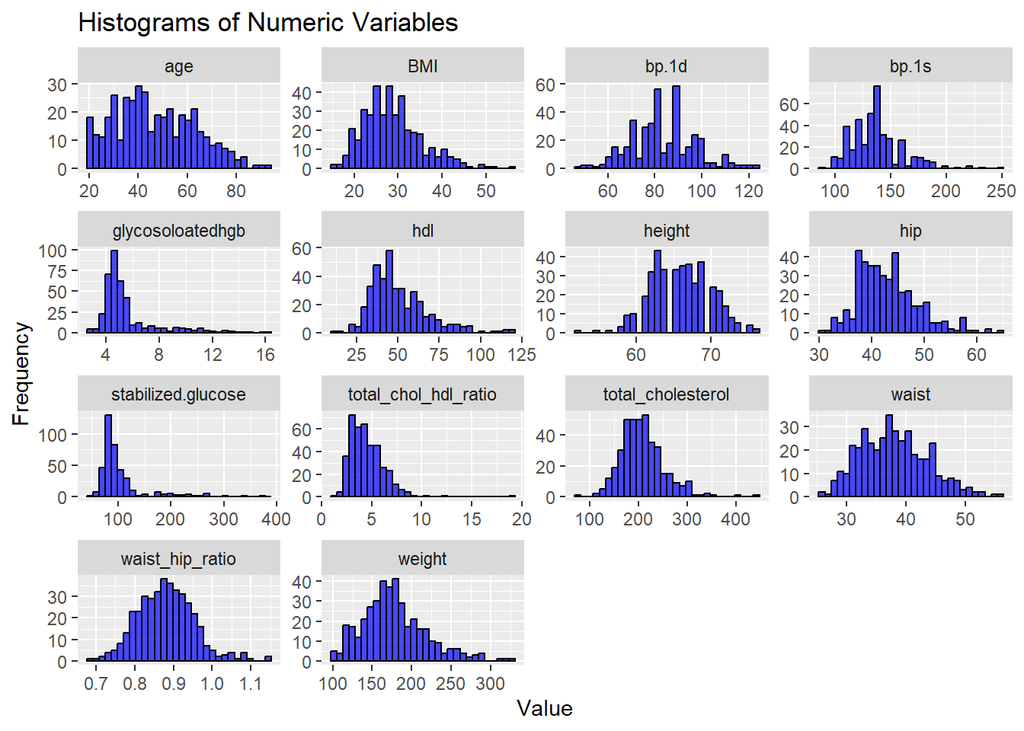

```r
# Reshape the data to long format
diabetes_long <- gather(diabetes, key = "variable", value = "value", -id, -location, -gender, -diabetes_diagnosis, -BMI_cat_5, -age_cat, -waist_hip_cat, -BMI_cat_3)

# Create a histogram for each variable with facets
ggplot(diabetes_long, aes(x = value)) +
  geom_histogram(fill = "blue", color = "black", alpha = 0.7) +
  labs(title = "Histograms of Numeric Variables",
       x = "Value",
       y = "Frequency") +
  facet_wrap(~variable, scales = "free")  # Creates a separate histogram for each variable
```

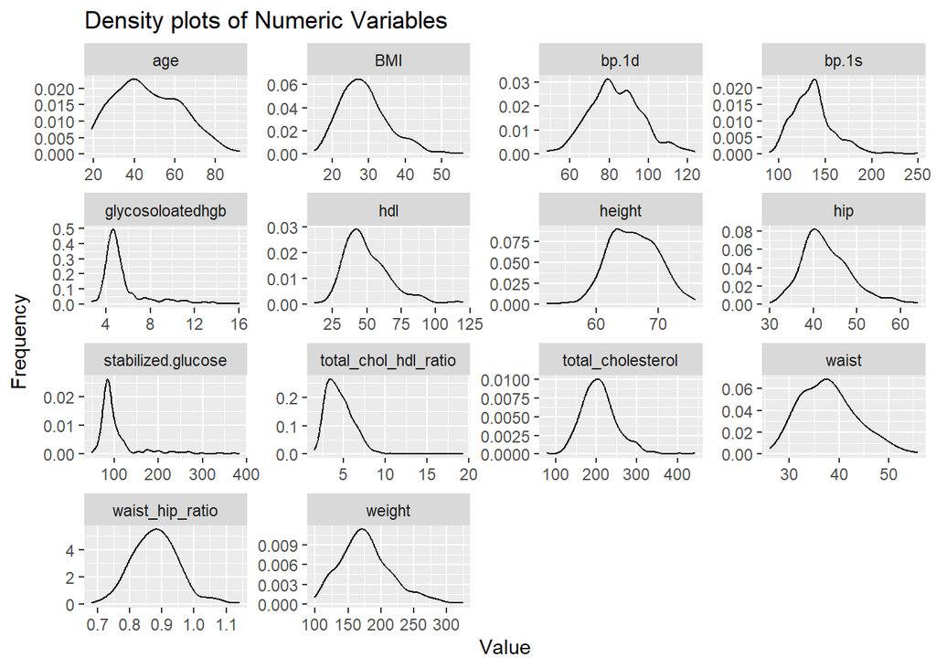

```r
# Create a density plots for each variable with facets
ggplot(diabetes_long, aes(x = value)) +
  geom_density() +
  labs(title = "Density plots of Numeric Variables",
       x = "Value",
       y = "Frequency") +
  facet_wrap(~variable, scales = "free")  # Creates a separate density plot for each variable
```

The first observations here suggest that some of the distributions are right-skewed (BMI, bp.1s, glukosoloatedhgb, stabilized.glucose) which means a significant proportion of individuals may fall within the normal or healthy range of the medical feature represented. However, attention should be given to the right tail of the distributions, as it represents individuals with elevated values. We might get crucial information and a better understanding of potential health risks by investigating possible associations between those features .

**Age:** The dataset appears to include only adults as the age distribution begins slightly below 20. There are more individuals with younger ages in the dataset, and the number of individuals decreases slightly as age increases. This is a common pattern, as populations often have a larger proportion of younger individuals, with the number of individuals tapering off as you move towards older age groups. The distribution is less peaked (~negative kurtosis) and has fewer outliers or extreme values in the tails. The ages are more concentrated around the mean, and there are fewer individuals with very high or very low ages.

**height:** There are slightly more individuals with taller heights in the dataset, and the number of individuals decreases slightly as height decreases. There are fewer outliers or extreme values in the taller range than the shorter.

**weight:** There seems to be some extreme values towards the heavier range. It could prove informative to investigate possible associations between this group and other features.

## Visualization of the amount of missing data

Showing in black the location of missing values, and also providing information on the overall percentage of missing values overall (in the legend), and in each variable.

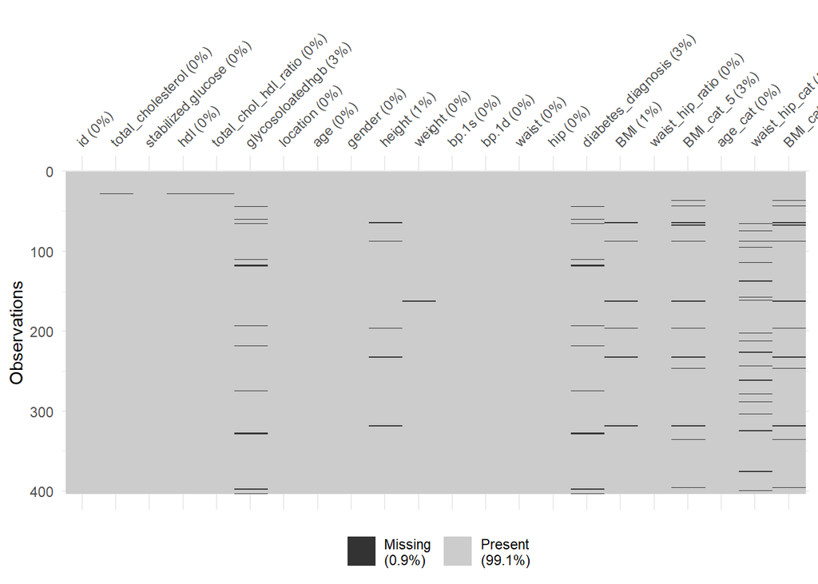

```r
vis_miss(diabetes)
```

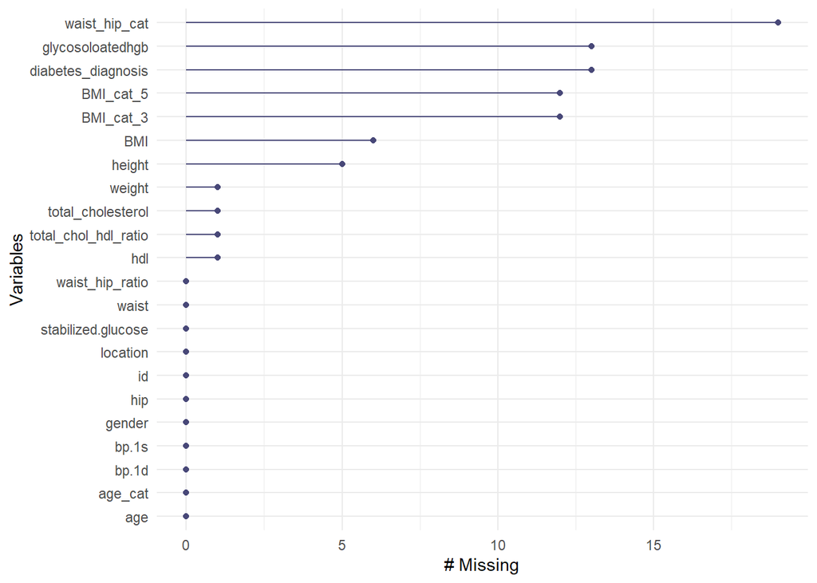

```r
gg_miss_var(diabetes)
```

## Investigating variables with diabetes_diagnosis as target class

Given the dataset’s context, which suggests its potential utility in constructing a predictive model for diabetes diagnosis, it is crucial to designate diabetes as the target variable. This focused approach facilitates a thorough exploration of features and relationships, providing valuable insights for informed model development.

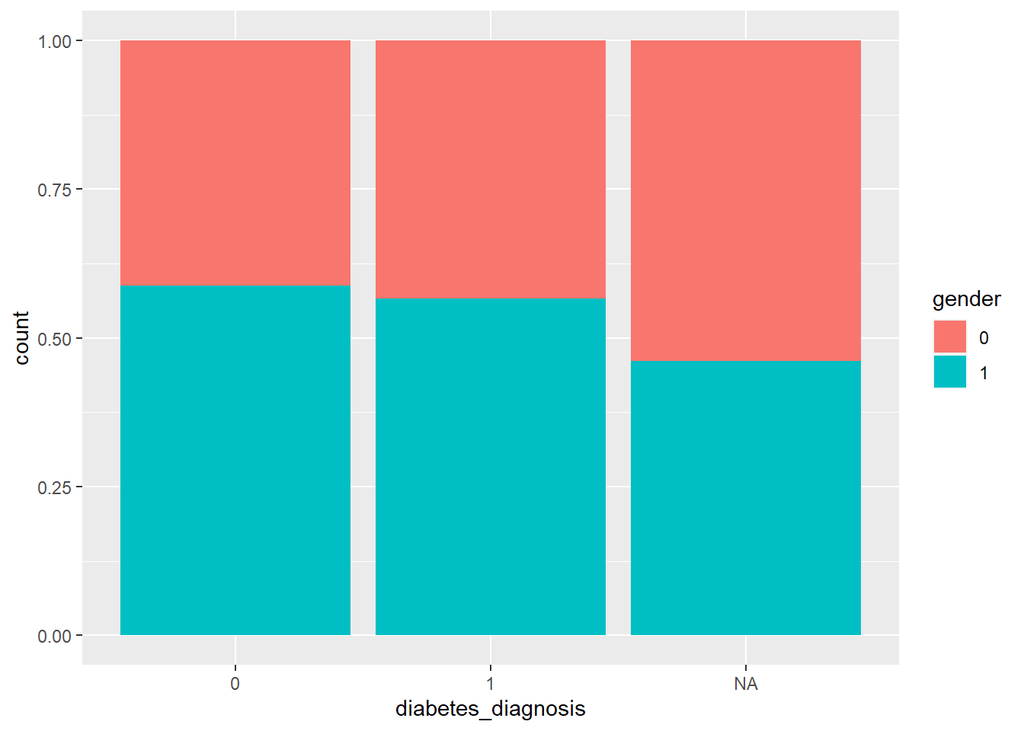

```r
# Create side-by-side bar chart of gender by diagnosis proportions
ggplot(diabetes, aes(x = diabetes_diagnosis, fill = gender)) +
  geom_bar(position = "fill",stat = "count")
```

The above plot indicates an equal distribution of diabetes diagnosis percentages between both genders.

In diabetes_diagnosis at level 0, the data indicates a predominant presence of individuals in the 2nd age category, with the 1st age category following closely. Conversely, at level 1 of diabetes_diagnosis, a significant proportion of individuals belong to age category 3, whereas those in the 1st age category constitute the minority.

In the second plot, it’s evident that the proportion of individuals in age category 3 at level 1 of diabetes_diagnosis far surpasses the proportion of the largest category at level 0.

Assuming the age categories are ordinal and knowing the dataset includes only adults we can infer that higher age categories are associated with a higher likelihood of diabetes.

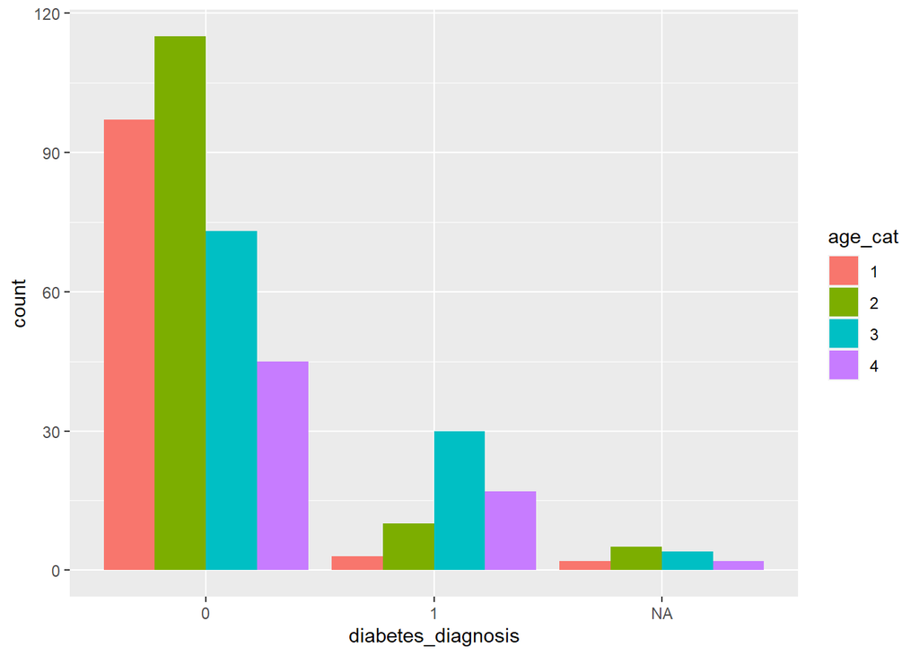

```r
# Create side-by-side bar chart of age_cat by diagnosis
ggplot(diabetes, aes(x = diabetes_diagnosis, fill = age_cat)) +
  geom_bar(position = "dodge")
```

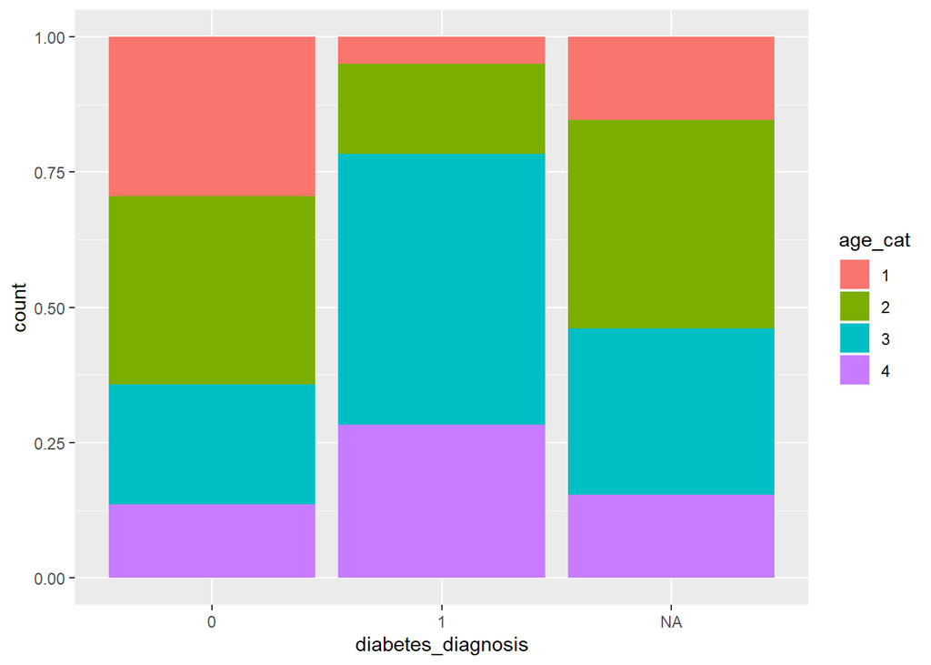

```r
# Create side-by-side bar chart of age_cat by diagnosis
ggplot(diabetes, aes(x = diabetes_diagnosis, fill = age_cat)) +
  geom_bar(position = "fill", stat = "count")
```

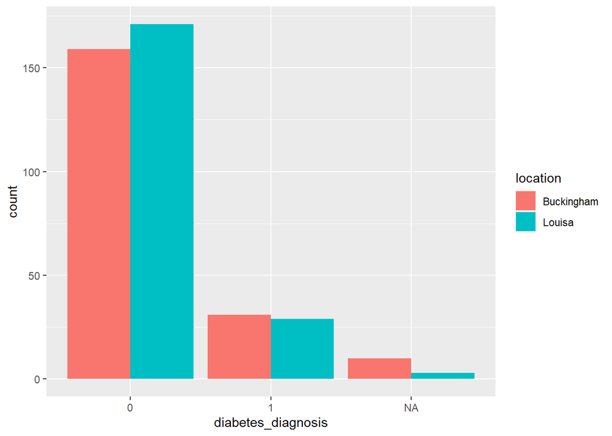

```r
# Create side-by-side bar chart of location by diagnosis
ggplot(diabetes, aes(x = diabetes_diagnosis, fill = location)) +
  geom_bar(position = "dodge")
```

The above plot indicates an approximately equal distribution of diabetes diagnosis percentages between both locations.

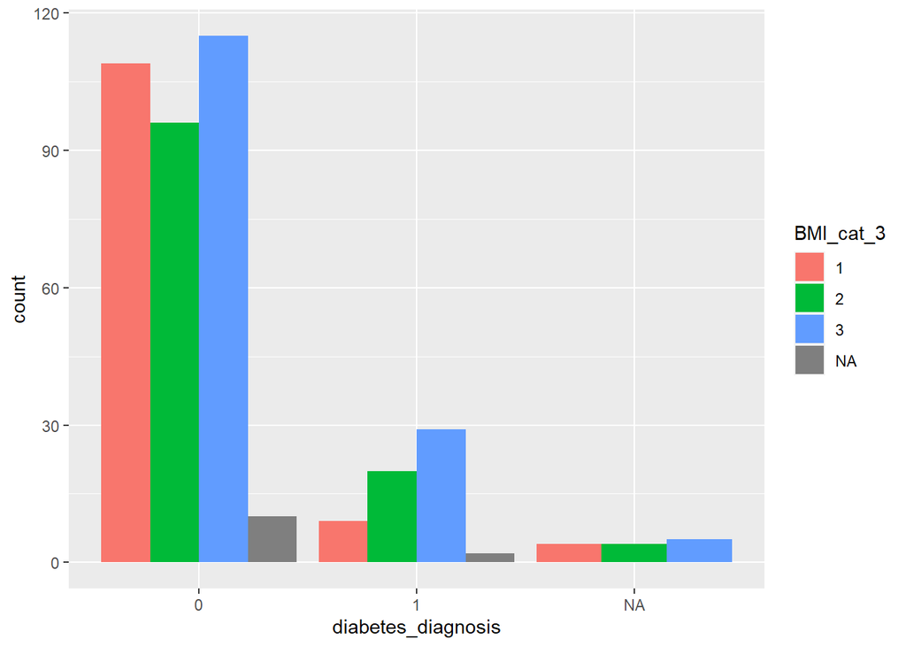

```r
# Create side-by-side bar chart of BMI_cat_3 by diagnosis
ggplot(diabetes, aes(x = diabetes_diagnosis, fill = BMI_cat_3)) +
  geom_bar(position = "dodge")
```

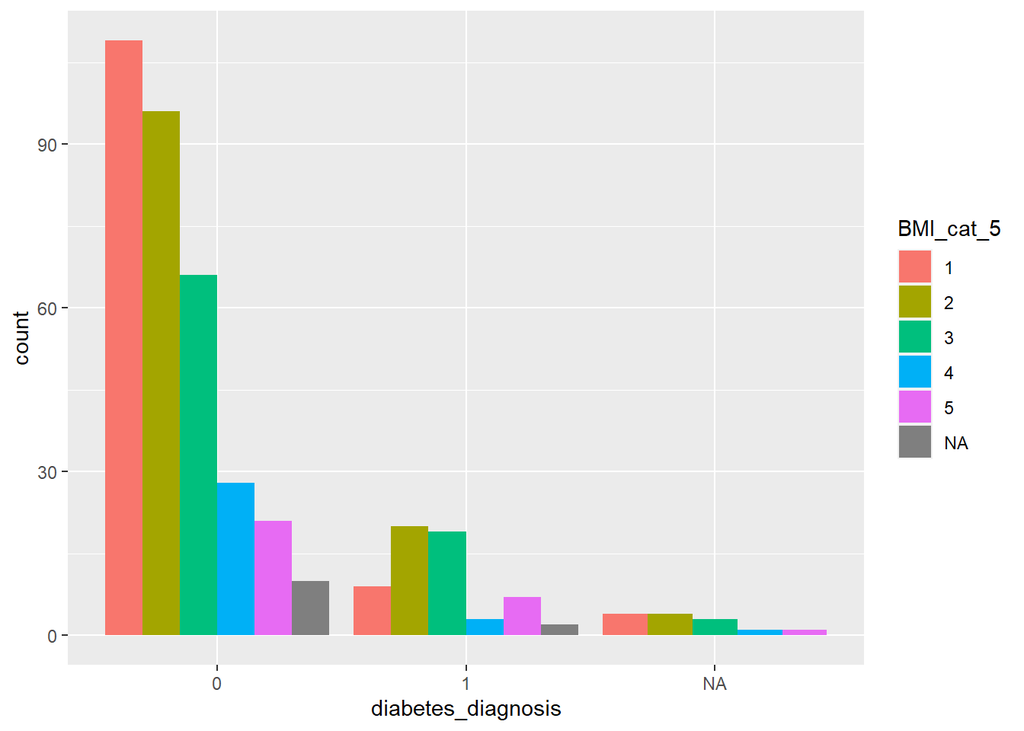

```r
# Create side-by-side bar chart of BMI_cat_5 by diagnosis
ggplot(diabetes, aes(x = diabetes_diagnosis, fill = BMI_cat_5)) +
  geom_bar(position = "dodge")
```

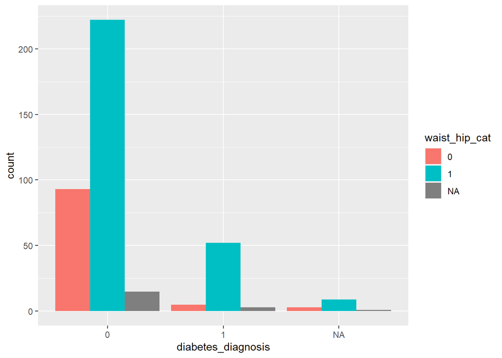

```r
# Create side-by-side bar chart of waist_hip_cat by diagnosis
ggplot(diabetes, aes(x = diabetes_diagnosis, fill = waist_hip_cat)) +
  geom_bar(position = "dodge")
```

Individuals at level 0 of wais_hip_ratio are less likely to be diagnosed with diabetes than those at level 1.

Below, the median length of diabetes stabilized glucose is greater than that of not-diabetes.

We can also infer that there is greater variability in stabilized glucose levels among individuals with diabetes.

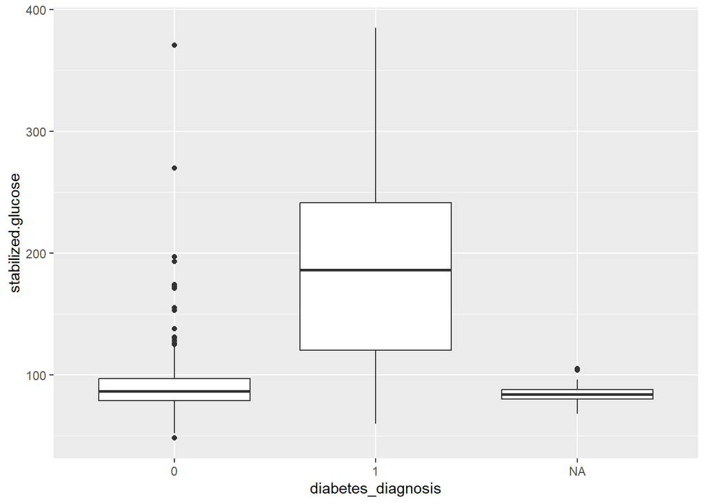

```r
ggplot(diabetes,aes(x = diabetes_diagnosis, y = stabilized.glucose)) +
  geom_boxplot()
```

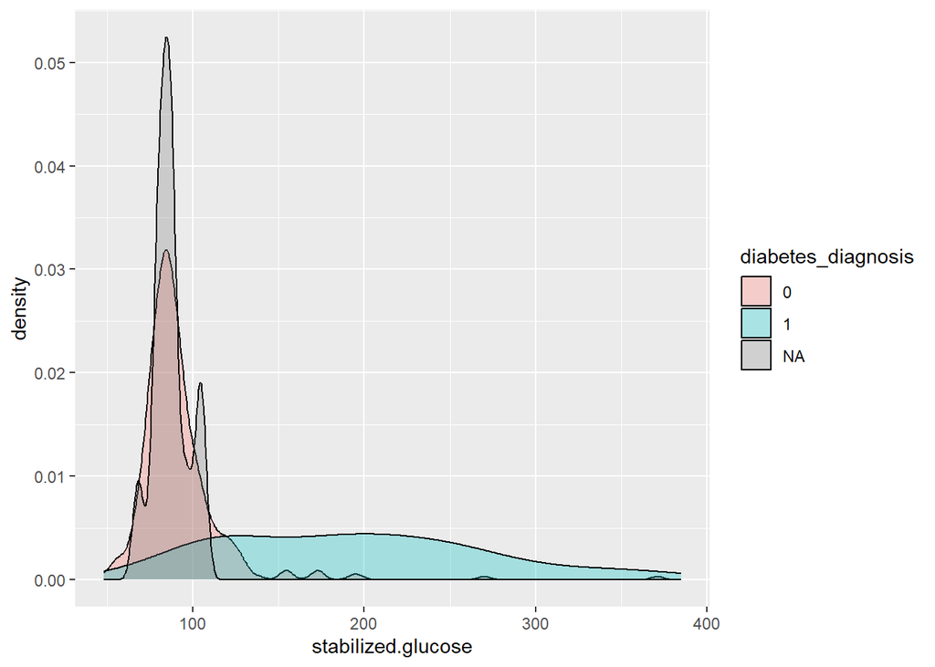

```r
ggplot(diabetes,aes(stabilized.glucose, fill = diabetes_diagnosis)) +
  geom_density(alpha = 0.3)
```

#### Visualizing relationships between numeric variables

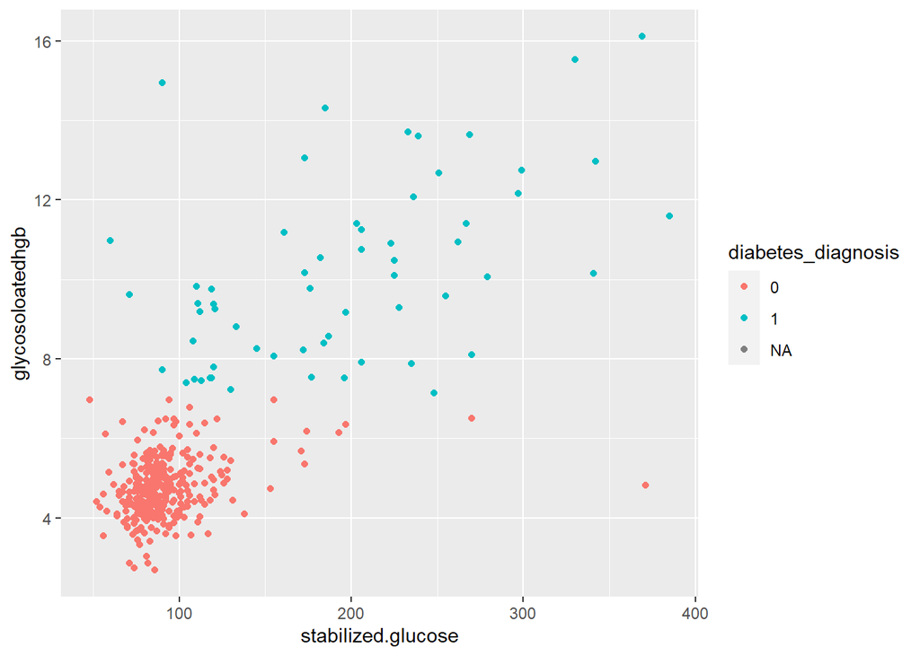

```r
ggplot(diabetes,aes(stabilized.glucose,glycosoloatedhgb, color = diabetes_diagnosis)) +
  geom_point()
```

The scatter plot reveals the presence of somewhat distinct clusters, implying the existence of potential subgroups within the dataset. These clusters align with different diabetes diagnoses, suggesting diverse patterns in the relationship between stabilized glucose and glycosoloatedhgb levels. Notably, within the diabetes_diagnosis variable, Level 1 data points exhibit a greater spread compared to Level 0. This indicates increased variability in stabilized glucose and glycosoloatedhgb levels among individuals diagnosed with Level 1 diabetes.

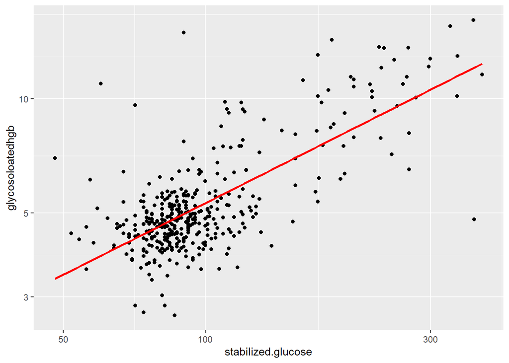

```r
ggplot(diabetes,aes(stabilized.glucose,glycosoloatedhgb)) +
  geom_point() +
  scale_x_log10() +
  scale_y_log10() +
  stat_smooth(method = "lm", formula = y ~ x, color = "red", se = FALSE)
```

It is observed a linear trend, which signifies that the logarithm of stabilized.glucose is linearly dependent from the logarithm of glycosoloatedhgb. There seems to be a positive correlation between the variables. However, the overlap in the lower left corner may also suggest that the relationship between stabilized glucose and glycosoloatedhgb is not strictly linear, especially at lower values.

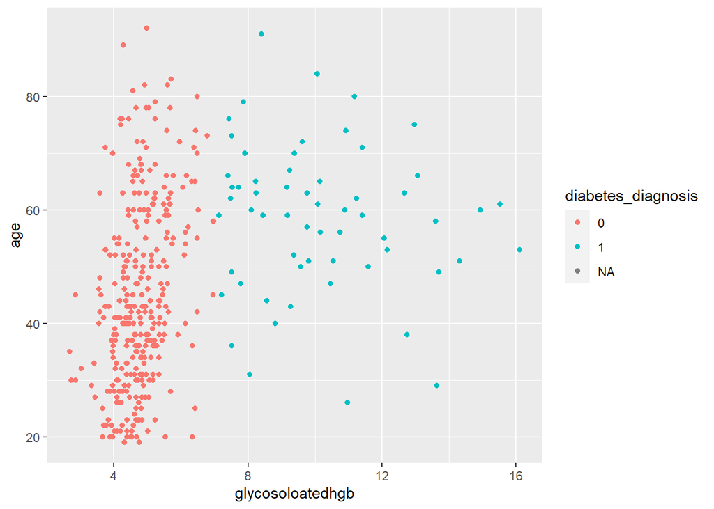

```r
ggplot(diabetes,aes(glycosoloatedhgb,age, color = diabetes_diagnosis)) +
  geom_point()
```

It is reasonable to conclude, that glycosoloatedhgb is a pivotal factor in diabetes diagnosis, given its consistent level of data point segregation observed here as well as in a prior scatter plot.

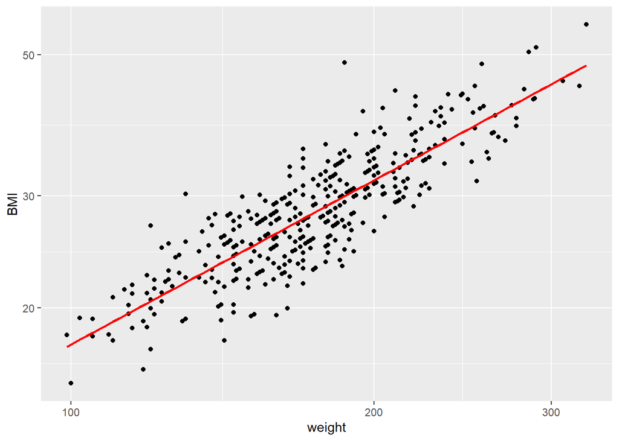

```r
ggplot(diabetes,aes(weight,BMI)) +
  geom_point() +
  scale_x_log10() +
  scale_y_log10() +
  stat_smooth(method = "lm", formula = y ~ x, color = "red", se = FALSE)
```

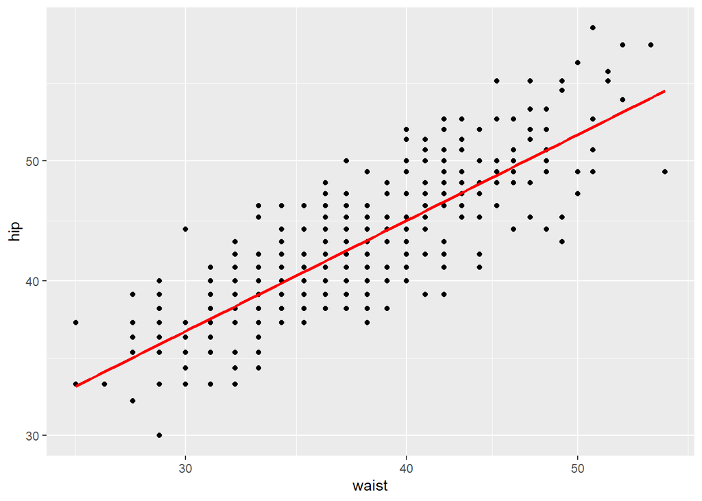

```r
ggplot(diabetes,aes(waist,hip)) +
  geom_point() +
  scale_x_log10() +
  scale_y_log10() +
  stat_smooth(method = "lm", formula = y ~ x, color = "red", se = FALSE)
```

Obviously, the correlation of weight and BMI is positive given BMI’s computation formula.

Similarly, as waist size increases, hip size increases as well.

An interesting observation appears in the scatter plot below as total_cholesterol exhibits no linear correlation with BMI or waist_hip_ratio.

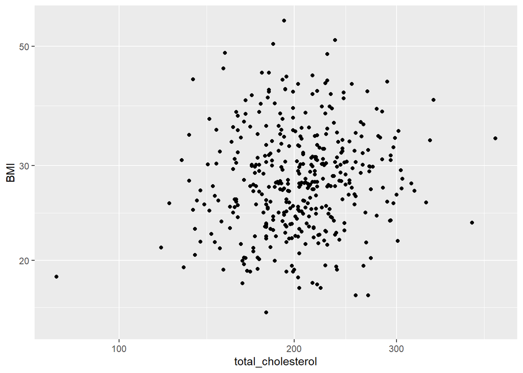

```r
ggplot(diabetes,aes(x = total_cholesterol, y = BMI)) +
  scale_x_log10() +
  scale_y_log10() +
  geom_point()
```

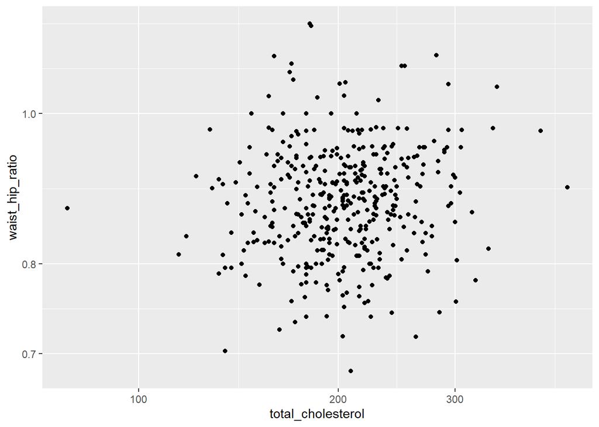

```r
ggplot(diabetes,aes(x = total_cholesterol, y = waist_hip_ratio)) +
  scale_x_log10() +
  scale_y_log10() +
  geom_point()
```

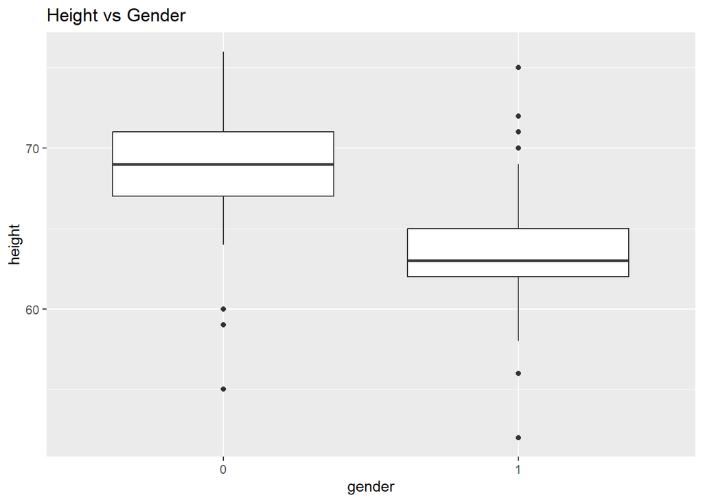

```r
ggplot(diabetes, aes(x = gender, y = height)) +
  geom_boxplot() +
  labs(title = "Height vs Gender")
```

Within the dataset, individuals of gender 0 tend to have higher median heights compared to individuals identified as gender 1. This suggests a general trend where gender 0 is predominantly taller than gender 1 based on the distribution of height values. It is reasonable to infer that gender 0 corresponds to males and gender 1 to females based on this observed pattern.

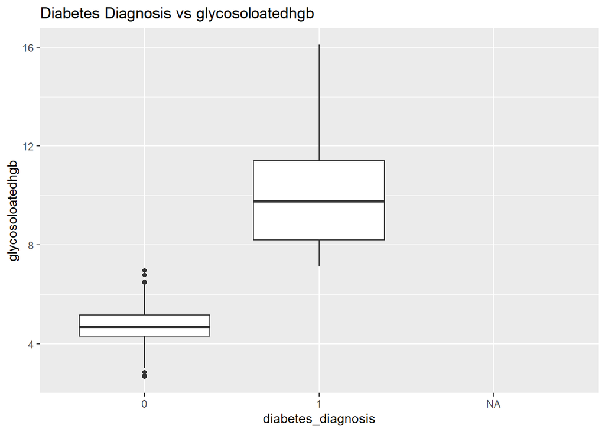

```r
ggplot(diabetes, aes(x = diabetes_diagnosis, y = glycosoloatedhgb)) +
  geom_boxplot() +
  labs(title = "Diabetes Diagnosis vs glycosoloatedhgb")
```

Consistent with earlier observations, it is reaffirmed here that glycosoloatedhgb serves as an indicative marker for diabetes. Individuals diagnosed with diabetes exhibit higher levels of glycosoloatedhgb compared to those without a diabetes diagnosis.

[figure not shown]

```r
ggplot(diabetes, aes(x = BMI_cat_5, y = bp.1d)) +
  geom_boxplot() +
  labs(title = "Diabetes Diagnosis vs glycosoloatedhgb")
```

As BMI increases median bp.1d increases as well with a slight decrease at level 5 of BMI.

## Part 2

### Reading data

```r
diabetes2 <- read.csv("diabetes2.csv", header=T, sep=",")
original <- diabetes[,c("total_cholesterol","age","gender","weight")]
str(diabetes2)
```

```
## 'data.frame':    403 obs. of  4 variables:
##  $ total_cholesterol: int  203 165 NA NA 249 NA NA 227 NA 263 ...
##  $ age              : int  46 NA NA 67 64 34 NA NA NA 55 ...
##  $ gender           : int  NA 1 1 0 0 0 NA 0 0 1 ...
##  $ weight           : int  121 NA 256 NA 183 190 191 NA NA 202 ...
```

```r
diabetes2$gender <- as.factor(diabetes2$gender)
```

The dataset consists of 403 records with 4 variables.The variable gender is categorical while the other three numerical.

## Statistics of missing values

There are 485 total missing values in the data. Below is their decomposition:

```r
colSums(is.na(diabetes2))
```

```
## total_cholesterol               age            gender            weight
##               114               135               122               114
```

The proportion of missings is 0.3008685 and proportion of complete values for the dataframe is 0.6991315.

```r
# Summarize missingness in each variable
miss_var_summary(diabetes2)
```

```
## # A tibble: 4 × 3
##   variable          n_miss pct_miss
##   <chr>              <int>    <dbl>
## 1 age                  135     33.5
## 2 gender               122     30.3
## 3 total_cholesterol    114     28.3
## 4 weight               114     28.3
```

```r
# Summarize missingness in each case
miss_case_summary(diabetes2)
```

```
## # A tibble: 403 × 3
##     case n_miss pct_miss
##    <int>  <int>    <dbl>
##  1     7      3       75
##  2     9      3       75
##  3    11      3       75
##  4    16      3       75
##  5    53      3       75
##  6    79      3       75
##  7    98      3       75
##  8   110      3       75
##  9   122      3       75
## 10   134      3       75
## # ℹ 393 more rows
```

According to theory, if missing data for a certain feature is more than 5%, then probably the feature should be left out. However, in this case if we follow this rule there will be no dataset left.

## Visualization of missing data

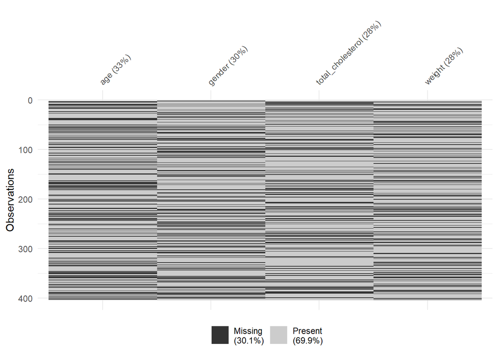

```r
# visualize and sort the columns by missingness
vis_miss(diabetes2, sort_miss = TRUE)
```

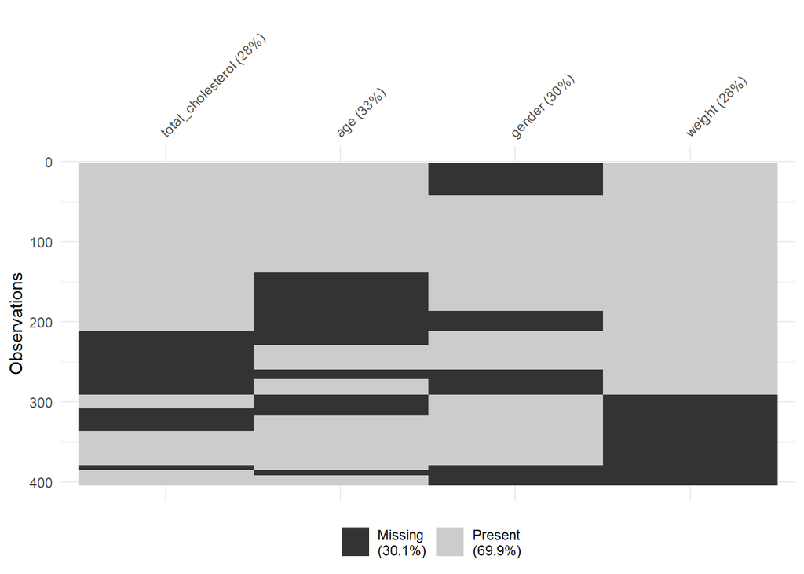

```r
# Visualize and cluster all of the missingness
vis_miss(diabetes2, cluster = TRUE)
```

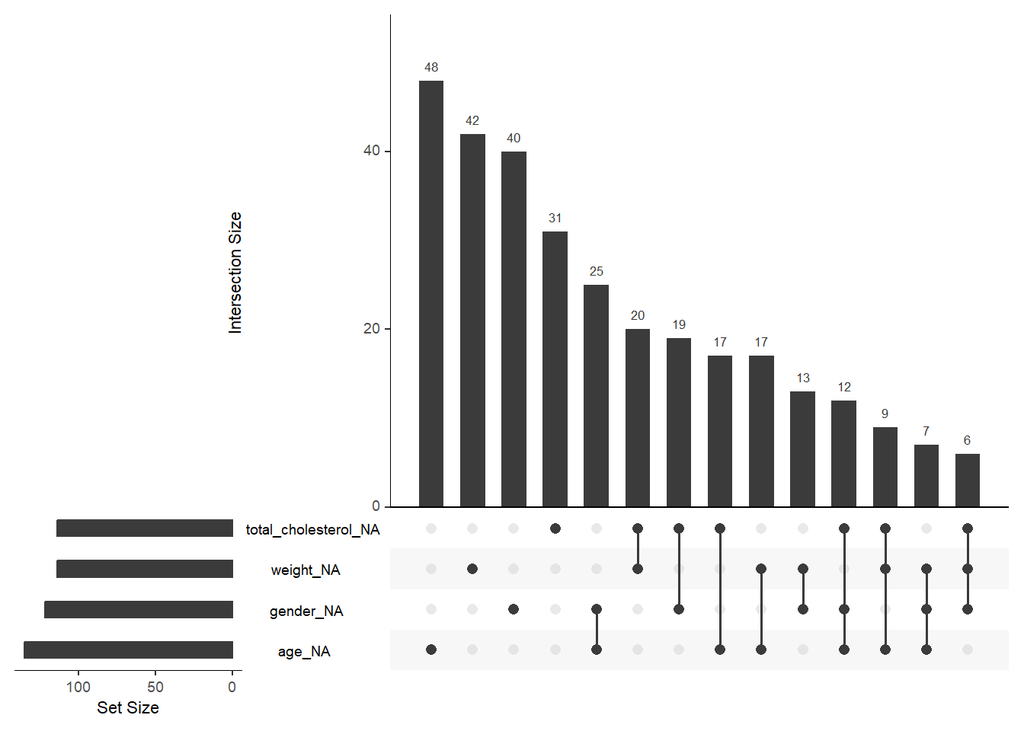

```r
# The missingness pattern
gg_miss_upset(diabetes2)
```

Exploring the possibility that older females may be hesitant to disclose their age due to societal norms, and individuals with higher body weight might prefer not to reveal this information, we can utilize these considerations and perhaps others, as a basis for imputation.

## Dealing with missing values

### Imputation

```r
init = mice(diabetes2, maxit=0)
meth = init$method
predM = init$predictorMatrix

predM[, c("total_cholesterol")]=0

# specify the methods for imputing the missing values
meth[c("age")]="norm"
meth[c("gender")]="logreg"
meth[c("weight")]="norm"

# run the multiple (m=5) imputation
set.seed(103)
imputed = mice(diabetes2, method=meth, predictorMatrix=predM, m=5)
# create a dataset after imputation
imputed <- complete(imputed)

# check for missings in the imputed dataset
colSums(is.na(imputed))
```

```
## total_cholesterol               age            gender            weight
##                 0                 0                 0                 0
```

```r
# Accuracy

# Weight
actual <- original$weight[is.na(diabetes2$weight)]
predicted <- imputed$weight[is.na(diabetes2$weight)]
mean(actual,na.rm = TRUE)
```

```
## [1] 178.9558
```

```r
mean(predicted)
```

```
## [1] 179.7026
```

```r
# Gender
actual <- original$gender[is.na(diabetes2$gender)]
predicted <- imputed$gender[is.na(diabetes2$gender)]
table(actual)
```

```
## actual
##  0  1
## 55 67
```

```r
table(predicted)
```

```
## predicted
##  0  1
## 54 68
```

```r
# total_cholesterol
actual <- original$total_cholesterol[is.na(diabetes2$total_cholesterol)]
predicted <- imputed$total_cholesterol[is.na(diabetes2$total_cholesterol)]
mean(actual,na.rm = TRUE)
```

```
## [1] 208.5841
```

```r
mean(predicted)
```

```
## [1] 211.5439
```

```r
# age
actual <- original$age[is.na(diabetes2$age)]
predicted <- imputed$age[is.na(diabetes2$age)]
mean(actual,na.rm = TRUE)
```

```
## [1] 46.34815
```

```r
mean(predicted)
```

```
## [1] 45.63173
```

The accuracy of the model seems satisfactory enough.

By removing rows with any missing value the means and medians of the original and removed one look close enough:

```r
# Remove rows with any missing values
removed <- na.omit(diabetes2)

# Check if there are still missing values in the new dataset
colSums(is.na(removed))
```

```
## total_cholesterol               age            gender            weight
##                 0                 0                 0                 0
```

```r
summary(removed)
```

```
##  total_cholesterol      age       gender     weight
##  Min.   :136.0     Min.   :20.0   0:43   Min.   : 99.0
##  1st Qu.:179.0     1st Qu.:35.0   1:54   1st Qu.:153.0
##  Median :208.0     Median :45.0          Median :169.0
##  Mean   :209.9     Mean   :46.9          Mean   :175.9
##  3rd Qu.:228.0     3rd Qu.:59.0          3rd Qu.:200.0
##  Max.   :342.0     Max.   :92.0          Max.   :290.0
```

```r
summary(original)
```

```
##  total_cholesterol      age        gender      weight
##  Min.   : 78.0     Min.   :19.00   0:169   Min.   : 99.0
##  1st Qu.:179.0     1st Qu.:34.00   1:234   1st Qu.:151.0
##  Median :204.0     Median :45.00           Median :172.5
##  Mean   :207.8     Mean   :46.85           Mean   :177.6
##  3rd Qu.:230.0     3rd Qu.:60.00           3rd Qu.:200.0
##  Max.   :443.0     Max.   :92.00           Max.   :325.0
##  NA's   :1                                 NA's   :1
```

If we assume that certain women may choose not to disclose their age and weight due to social conventions, one approach could involve imputing the missing gender as female (1) in instances where either age or weight is missing along with gender.

```r
imputed_gender <- data.frame(diabetes2)

imputed_gender[is.na(imputed_gender$gender) & (is.na(imputed_gender$age) | is.na(imputed_gender$weight)), 'gender'] <- 1
imputed_gender[is.na(imputed_gender$gender), 'gender'] <- 0

# Gender
actual <- original$gender[is.na(diabetes2$gender)]
predicted <- imputed_gender$gender[is.na(diabetes2$gender)]
table(actual)
```

```
## actual
##  0  1
## 55 67
```

```r
table(predicted)
```

```
## predicted
##  0  1
## 59 63
```

```r
# Create a data frame with actual and predicted values
results <- data.frame(gender_true = original$gender, gender_pred = imputed_gender$gender)

# Compute confusion matrix
conf_matrix <- table(results$gender_true, results$gender_pred)

# Compute precision
precision <- conf_matrix[2, 2] / sum(conf_matrix[, 2])

# Compute recall
recall <- conf_matrix[2, 2] / sum(conf_matrix[2, ])

precision
```

```
## [1] 0.8652174
```

```r
recall
```

```
## [1] 0.8504274
```

The predicted values do not seem far of.

In conclusion, the application of the MICE package appears to yield satisfactory results in handling missing values within the given diabetes dataset. The evaluation of imputation accuracy through mean comparisons between actual and imputed values for the variables suggests that the imputed values align closely with the observed data. This indicates that the MICE imputation method effectively captures the underlying patterns in the dataset.

Comparing this imputation strategy with the alternative of removing rows with any missing values reveals that imputation retains more information, supporting the notion that imputing missing values can be a beneficial approach in preserving dataset integrity.

Additionally, addressing potential missingness in the gender variable by imputing values based on the presence of missing age or weight values is an unpredictable approach since it is based on assumptions. The evaluation of imputed gender values through precision and recall metrics, along with a confusion matrix, provides a more nuanced assessment of imputation quality.